# Lifestyle Habits and Work Productivity Analysis

```r
library(tidyverse)
library(ggplot2)
df <- read_csv("data.csv")
head(df)
```

| Date | Person_ID | Age | Gender | Sleep Start Time | Sleep End Time | Total Sleep Hours | Sleep Quality | Exercise (mins/day) | Caffeine Intake (mg) | Screen Time Before Bed (mins) | Work Hours (hrs/day) | Productivity Score | Mood Score | Stress Level |
| --- | --- | --- | --- | --- | --- | --- | --- | --- | --- | --- | --- | --- | --- | --- |
| 4/3/2024 | 7883 | 40 | Female | 21.77 | 6.02 | 8.25 | 10 | 75 | 168 | 7 | 11.630672 | 9 | 5 | 9 |
| 11/30/2024 | 9313 | 45 | Female | 20.17 | 2.98 | 6.81 | 4 | 4 | 181 | 109 | 4.278893 | 9 | 3 | 2 |
| 5/10/2024 | 7200 | 21 | Male | 21.60 | 6.93 | 9.33 | 1 | 79 | 138 | 147 | 4.531243 | 6 | 2 | 1 |
| 11/25/2024 | 4597 | 52 | Male | 21.27 | 3.50 | 6.24 | 3 | 57 | 293 | 153 | 10.282357 | 9 | 9 | 6 |
| 11/24/2024 | 2817 | 56 | Male | 22.68 | 3.52 | 4.84 | 2 | 67 | 276 | 158 | 8.163985 | 5 | 7 | 10 |
| 7/20/2024 | 7575 | 25 | Male | 21.47 | 5.01 | 7.54 | 10 | 8 | 30 | 95 | 6.470274 | 5 | 5 | 6 |

```r
summary(df)
```

```
     Date             Person_ID         Age           Gender          Sleep Start Time Sleep End Time
 Length:2500        Min.   :1003   Min.   :18.00   Length:2500        Min.   :20.00    Min.   :0.73
 Class :character   1st Qu.:3239   1st Qu.:28.00   Class :character   1st Qu.:21.02    1st Qu.:3.69
 Mode  :character   Median :5599   Median :38.00   Mode  :character   Median :22.02    Median :5.01
                    Mean   :5512   Mean   :38.39                      Mean   :22.02    Mean   :5.00
                    3rd Qu.:7743   3rd Qu.:49.00                      3rd Qu.:23.02    3rd Qu.:6.26
                    Max.   :9997   Max.   :59.00                      Max.   :23.98    Max.   :9.42
 Total Sleep Hours Sleep Quality    Exercise (mins/day) Caffeine Intake (mg)
 Min.   :4.500     Min.   : 1.000   Min.   : 0.00       Min.   :  0.00
 1st Qu.:5.720     1st Qu.: 3.000   1st Qu.:22.00       1st Qu.: 73.75
 Median :6.940     Median : 5.000   Median :44.00       Median :148.00
 Mean   :6.984     Mean   : 5.492   Mean   :44.11       Mean   :148.52
 3rd Qu.:8.210     3rd Qu.: 8.000   3rd Qu.:66.00       3rd Qu.:224.00
 Max.   :9.500     Max.   :10.000   Max.   :89.00       Max.   :299.00
 Screen Time Before Bed (mins) Work Hours (hrs/day) Productivity Score   Mood Score
 Min.   :  0.00                Min.   : 4.000       Min.   : 1.000     Min.   : 1.000
 1st Qu.: 46.00                1st Qu.: 6.046       1st Qu.: 5.000     1st Qu.: 3.000
 Median : 93.00                Median : 8.026       Median : 7.000     Median : 5.000
 Mean   : 91.58                Mean   : 8.000       Mean   : 6.486     Mean   : 5.346
 3rd Qu.:136.00                3rd Qu.: 9.926       3rd Qu.: 8.000     3rd Qu.: 8.000
 Max.   :179.00                Max.   :11.998       Max.   :10.000     Max.   :10.000
  Stress Level
 Min.   : 1.000
 1st Qu.: 3.000
 Median : 6.000
 Mean   : 5.602
 3rd Qu.: 8.000
 Max.   :10.000
```

```r
str(df)
```

```
spc_tbl_ [2,500 × 15] (S3: spec_tbl_df/tbl_df/tbl/data.frame)
 $ Date                         : chr [1:2500] "4/3/2024" "11/30/2024" "5/10/2024" "11/25/2024" ...
 $ Person_ID                    : num [1:2500] 7883 9313 7200 4597 2817 ...
 $ Age                          : num [1:2500] 40 45 21 52 56 25 18 27 26 59 ...
 $ Gender                       : chr [1:2500] "Female" "Female" "Male" "Male" ...
 $ Sleep Start Time             : num [1:2500] 21.8 20.2 21.6 21.3 22.7 ...
 $ Sleep End Time               : num [1:2500] 6.02 2.98 6.93 3.5 3.52 5.01 3.69 5.23 2.31 1.93 ...
 $ Total Sleep Hours            : num [1:2500] 8.25 6.81 9.33 6.24 4.84 7.54 7.42 6.68 5.01 4.94 ...
 $ Sleep Quality                : num [1:2500] 10 4 1 3 2 10 2 9 4 9 ...
 $ Exercise (mins/day)          : num [1:2500] 75 4 79 57 67 8 36 73 63 57 ...
 $ Caffeine Intake (mg)         : num [1:2500] 168 181 138 293 276 30 161 292 154 1 ...
 $ Screen Time Before Bed (mins): num [1:2500] 7 109 147 153 158 95 172 133 134 77 ...
 $ Work Hours (hrs/day)         : num [1:2500] 11.63 4.28 4.53 10.28 8.16 ...
 $ Productivity Score           : num [1:2500] 9 9 6 9 5 5 5 6 8 8 ...
 $ Mood Score                   : num [1:2500] 5 3 2 9 7 5 3 9 3 4 ...
 $ Stress Level                 : num [1:2500] 9 2 1 6 10 6 2 9 4 8 ...
 - attr(*, "spec")=
  .. cols(
  ..   Date = col_character(),
  ..   Person_ID = col_double(),
  ..   Age = col_double(),
  ..   Gender = col_character(),
  ..   `Sleep Start Time` = col_double(),
  ..   `Sleep End Time` = col_double(),
  ..   `Total Sleep Hours` = col_double(),
  ..   `Sleep Quality` = col_double(),
  ..   `Exercise (mins/day)` = col_double(),
  ..   `Caffeine Intake (mg)` = col_double(),
  ..   `Screen Time Before Bed (mins)` = col_double(),
  ..   `Work Hours (hrs/day)` = col_double(),
  ..   `Productivity Score` = col_double(),
  ..   `Mood Score` = col_double(),
  ..   `Stress Level` = col_double()
  .. )
 - attr(*, "problems")=<externalptr>
```

```r
colSums(is.na(df))
```

```
                         Date                     Person_ID                           Age
                            0                             0                             0
                       Gender              Sleep Start Time                Sleep End Time
                            0                             0                             0
            Total Sleep Hours                 Sleep Quality           Exercise (mins/day)
                            0                             0                             0
         Caffeine Intake (mg) Screen Time Before Bed (mins)          Work Hours (hrs/day)
                            0                             0                             0
           Productivity Score                    Mood Score                  Stress Level
                            0                             0                             0
```

```r
df <- df %>% rename(
  "ID" = "Person_ID",
  "Sleep Start" = "Sleep Start Time",
  "Sleep End" = "Sleep End Time",
  "Sleep Hours" = "Total Sleep Hours" ,
  "Exercise Time" = "Exercise (mins/day)",
  "Caffeine" = "Caffeine Intake (mg)",
  "Screen Time" = "Screen Time Before Bed (mins)",
  "Work Hours" = "Work Hours (hrs/day)",
  "Prod Score" = "Productivity Score",
  "Mood" = "Mood Score",
  "Stress" = "Stress Level"
)
```

```r
length(unique(df$ID))
```

```
[1] 2192
```

```r
counts <- table(df$ID)
counts[counts > 3]
```

```
5597
   4
```

```r
df[df$ID %in% c(5597),]
```

| Date | ID | Age | Gender | Sleep Start | Sleep End | Sleep Hours | Sleep Quality | Exercise Time | Caffeine | Screen Time | Work Hours | Prod Score | Mood | Stress |
| --- | --- | --- | --- | --- | --- | --- | --- | --- | --- | --- | --- | --- | --- | --- |
| 10/11/2024 | 5597 | 33 | Male | 21.60 | 2.39 | 4.79 | 7 | 40 | 231 | 92 | 4.139986 | 6 | 5 | 1 |
| 12/7/2024 | 5597 | 46 | Male | 23.15 | 5.72 | 6.57 | 6 | 20 | 162 | 82 | 9.104417 | 4 | 3 | 4 |
| 4/26/2024 | 5597 | 48 | Male | 20.58 | 6.01 | 9.43 | 8 | 23 | 220 | 172 | 6.340062 | 10 | 8 | 3 |
| 11/13/2024 | 5597 | 31 | Male | 21.07 | 2.08 | 5.02 | 9 | 53 | 222 | 143 | 5.085702 | 10 | 3 | 6 |

```r
df <- df %>% select(-`ID`, -`Date`)
head(df)
```

| Age | Gender | Sleep Start | Sleep End | Sleep Hours | Sleep Quality | Exercise Time | Caffeine | Screen Time | Work Hours | Prod Score | Mood | Stress |
| --- | --- | --- | --- | --- | --- | --- | --- | --- | --- | --- | --- | --- |
| 40 | Female | 21.77 | 6.02 | 8.25 | 10 | 75 | 168 | 7 | 11.630672 | 9 | 5 | 9 |
| 45 | Female | 20.17 | 2.98 | 6.81 | 4 | 4 | 181 | 109 | 4.278893 | 9 | 3 | 2 |
| 21 | Male | 21.60 | 6.93 | 9.33 | 1 | 79 | 138 | 147 | 4.531243 | 6 | 2 | 1 |
| 52 | Male | 21.27 | 3.50 | 6.24 | 3 | 57 | 293 | 153 | 10.282357 | 9 | 9 | 6 |
| 56 | Male | 22.68 | 3.52 | 4.84 | 2 | 67 | 276 | 158 | 8.163985 | 5 | 7 | 10 |
| 25 | Male | 21.47 | 5.01 | 7.54 | 10 | 8 | 30 | 95 | 6.470274 | 5 | 5 | 6 |

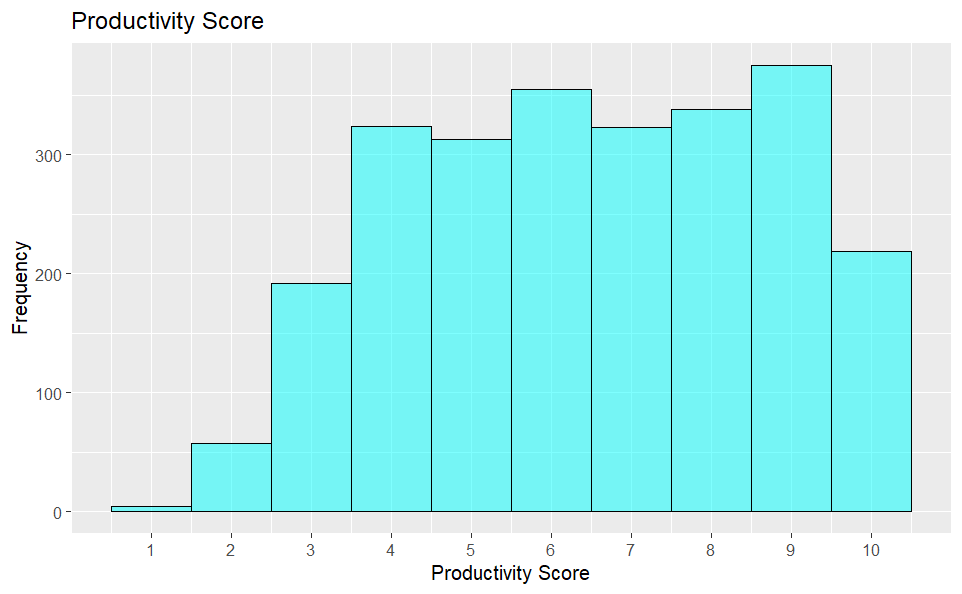

```r
ggplot(df, aes(x = `Prod Score`)) +
  geom_histogram(binwidth = 1, fill = "cyan", color = "black", alpha = 0.5) +
  scale_x_continuous(breaks = 1:10) +
  labs(
    title = "Productivity Score", x = "Productivity Score", y = "Frequency")
```

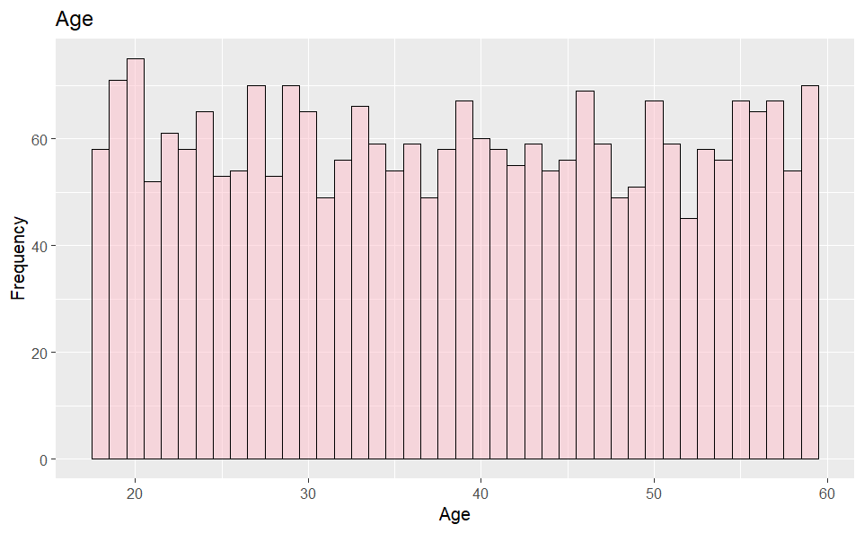

```r
ggplot(df, aes(x = `Age`)) +
  geom_histogram(binwidth = 1, fill = "pink", color = "black", alpha = 0.5) +
  labs(title = "Age", x = "Age", y = "Frequency")
```

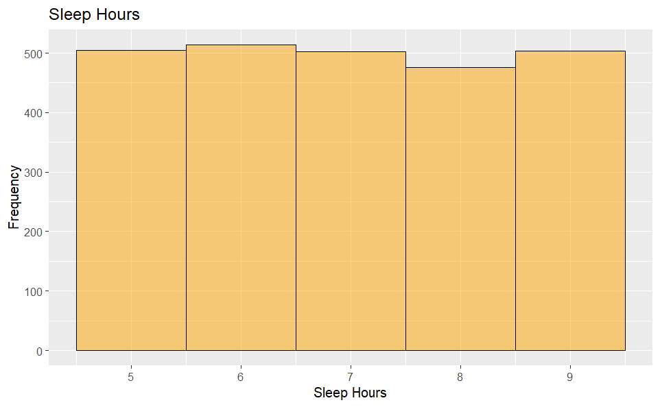

```r
ggplot(df, aes(x = `Sleep Hours`)) +
  geom_histogram(binwidth = 1, fill = "orange", color = "black", alpha = 0.5) +
  labs(title = "Sleep Hours", x = "Sleep Hours", y = "Frequency")
```

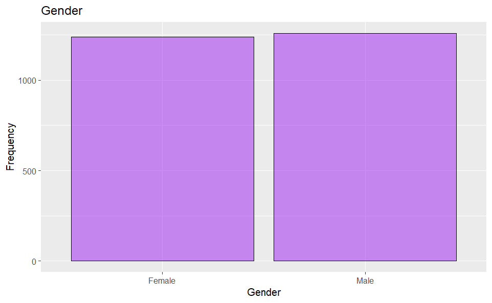

```r
ggplot(df, aes(x = `Gender`)) +
  geom_histogram(stat = "count", fill = "purple", color = "black", alpha = 0.5) +
  labs(title = "Gender", x = "Gender", y = "Frequency")
```

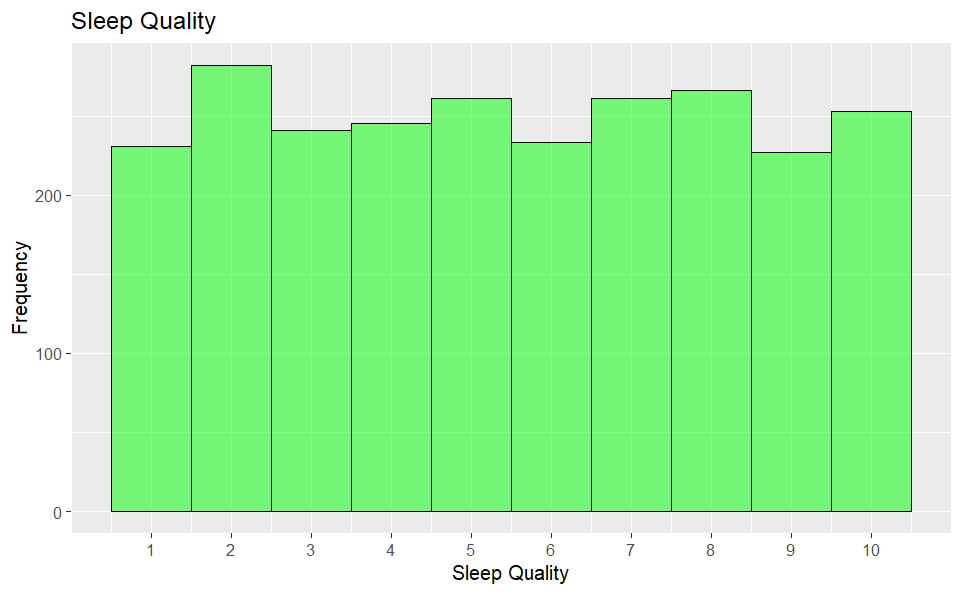

```r
ggplot(df, aes(x = `Sleep Quality`)) +
  geom_histogram(binwidth = 1, fill = "green", color = "black", alpha = 0.5) +
  scale_x_continuous(breaks = 1:10) +
  labs(title = "Sleep Quality", x = "Sleep Quality", y = "Frequency")
```

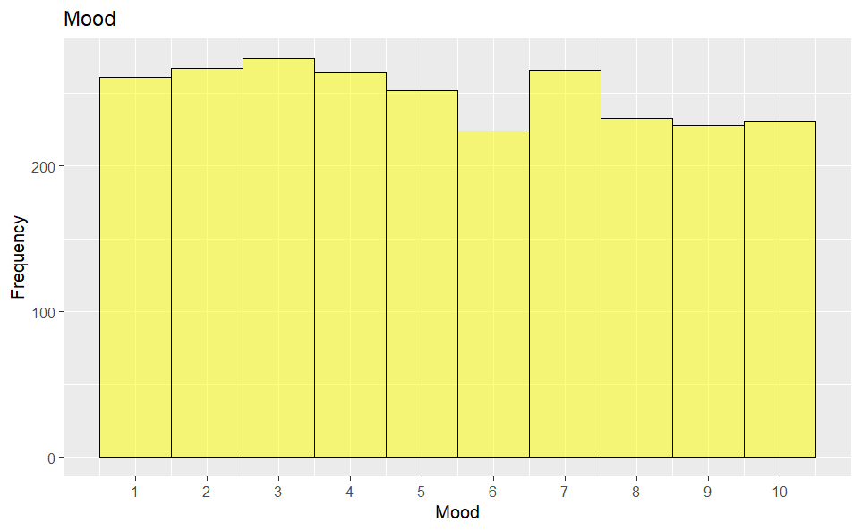

```r
ggplot(df, aes(x = `Mood`)) +
  geom_histogram(binwidth = 1, fill = "yellow", color = "black", alpha = 0.5) +
  scale_x_continuous(breaks = 1:10) +
  labs(title = "Mood", x = "Mood", y = "Frequency")
```

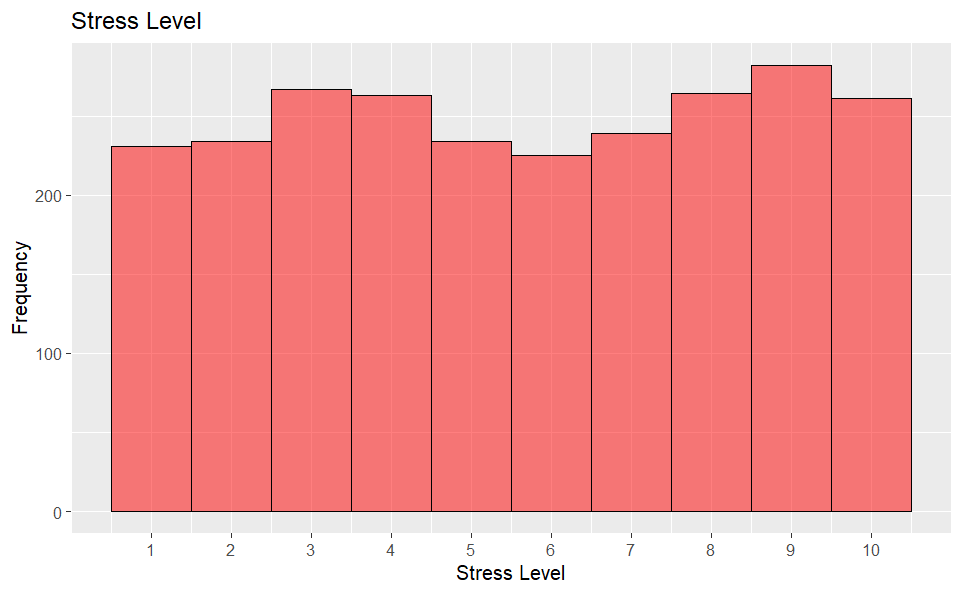

```r
ggplot(df, aes(x = `Stress`)) +
  geom_histogram(binwidth = 1, fill = "red", color = "black", alpha = 0.5) +
  scale_x_continuous(breaks = 1:10) +
  labs(title = "Stress Level", x = "Stress Level",y = "Frequency")
```

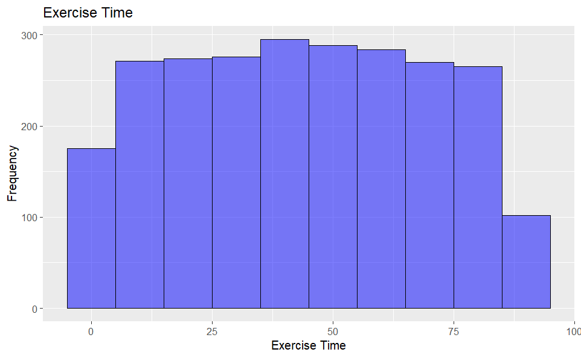

```r
ggplot(df, aes(x = `Exercise Time`)) +
  geom_histogram(binwidth = 10, fill = "blue", color = "black", alpha = 0.5) +
  labs(title = "Exercise Time", x = "Exercise Time",y = "Frequency")
```

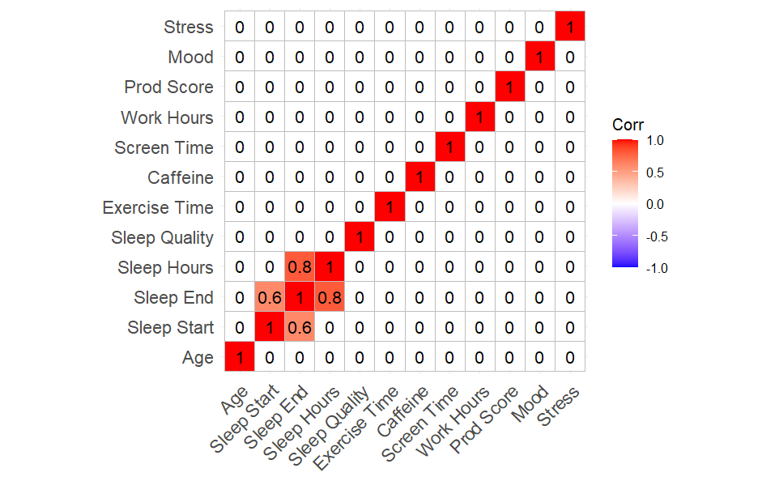

```r
library(ggcorrplot)
corr_mat = round(cor(df[sapply(df, is.numeric)]),1)
ggcorrplot(corr_mat, lab = TRUE)
```

One Sample T-Test: 1.) H0: Average sleep quality is 7. Ha: Average sleep quality is not equal to 7 2.) H0: Average productivity score is 7 Ha: Average productivity score is not equal to 7

Two Sample T-Test: 1.) H0: There is no difference in average sleep quality of males and females. Ha: There is difference in average sleep quality of males and females. 2.) H0: There is no difference in average work hours between individuals with low stress and those with high stress. Ha: There is difference in average work hours between individuals with low stress and those with high stress.

ANOVA: 1.) H0: Productivity Score is same across different age group Ha: Productivity Score is different across different age group 2.) H0: Productivity Score is same across different stress levels Ha: Productivity Score is different across different stress levels

One Sample T-Test: H0: Average sleep quality is 7. Ha: Average sleep quality is not equal to 7

```r
t_test_sleep_quality <- t.test(df$`Sleep Quality`, mu = 7)
print("Sleep Quality T Test")
```

```
[1] "Sleep Quality T Test"
```

```r
print(t_test_sleep_quality)
```

```
    One Sample t-test

data:  df$`Sleep Quality`
t = -26.354, df = 2499, p-value < 2.2e-16
alternative hypothesis: true mean is not equal to 7
95 percent confidence interval:
 5.379364 5.603836
sample estimates:
mean of x
   5.4916
```

H0: Average productivity score is 7 Ha: Average productivity score is not equal to 7

```r
t_test_prod_score <- t.test(df$`Prod Score`, mu = 7)
print("Productivity Score T Test")
```

```
[1] "Productivity Score T Test"
```

```r
print(t_test_prod_score)
```

```
    One Sample t-test

data:  df$`Prod Score`
t = -11.578, df = 2499, p-value < 2.2e-16
alternative hypothesis: true mean is not equal to 7
95 percent confidence interval:
 6.398948 6.573052
sample estimates:
mean of x
    6.486
```

H0: There is no difference in average sleep quality of males and females. Ha: There is difference in average sleep quality of males and females.

```r
male_df <- subset(df, `Gender` == "Male", select = `Sleep Quality`)
female_df <- subset(df, `Gender` == "Female", select = `Sleep Quality`)
t_test_gender_sleep <- t.test(male_df$`Sleep Quality`, female_df$`Sleep Quality`, var.equal = TRUE)
print("Gender's Sleep Quality T-Test")
```

```
[1] "Gender's Sleep Quality T-Test"
```

```r
print(t_test_gender_sleep)
```

```
    Two Sample t-test

data:  male_df$`Sleep Quality` and female_df$`Sleep Quality`
t = 0.9726, df = 2498, p-value = 0.3308
alternative hypothesis: true difference in means is not equal to 0
95 percent confidence interval:
 -0.1131393  0.3358224
sample estimates:
mean of x mean of y
 5.546825  5.435484
```

H0: There is no difference in average work hours between individuals with low stress and those with high stress. Ha: There is difference in average work hours between individuals with low stress and those with high stress.